# Intuicyjne kolorowanie wykresów

2022-11-22

# Eksperyment polegał na zbadaniu wpływu dobrego i intuicyjnego kolorowania na zapamiętywanie danych z wykresów. W tym celu ankietowanym zostały pokazane 4 wykresy pokolorowane na różne sposoby: • dobre kolorowanie • błędny kolor kolumn • błędny kolor osi x, brak kolorowania kolumn • błędny kolor osi x oraz kolumn Zadaniem badanych było posegregowanie kolorów od tego z najwyższym słupkiem do tego z najniższym. Na każdy wykres mogli oni patrzeć przez 10 sekund.

# Wykresy z ankiety

###### *Kliknięcie wykresu spowoduje jego powiększenie*

## 1.) Dobre kolorowanie

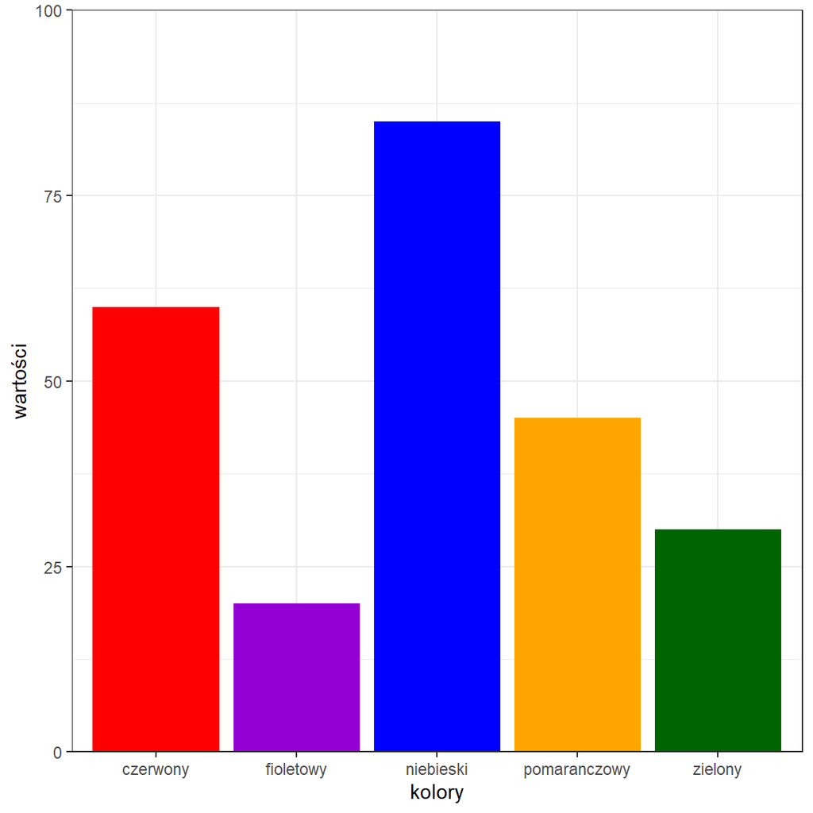

**Oczekiwana odpowiedź:** niebieski, czerwony, pomarańczowy, zielony, fioletowy

## 2.) Błędny kolor kolumn

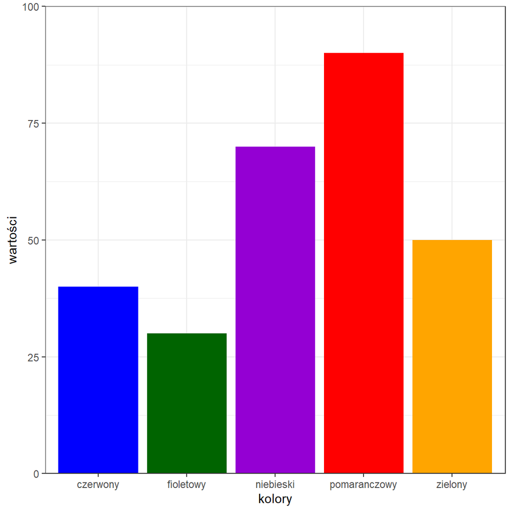

**Oczekiwana odpowiedź:** pomarańczowy, niebieski, zielony, czerwony, fioletowy

## 3.) Błędny kolor osi x, brak kolorowania kolumn

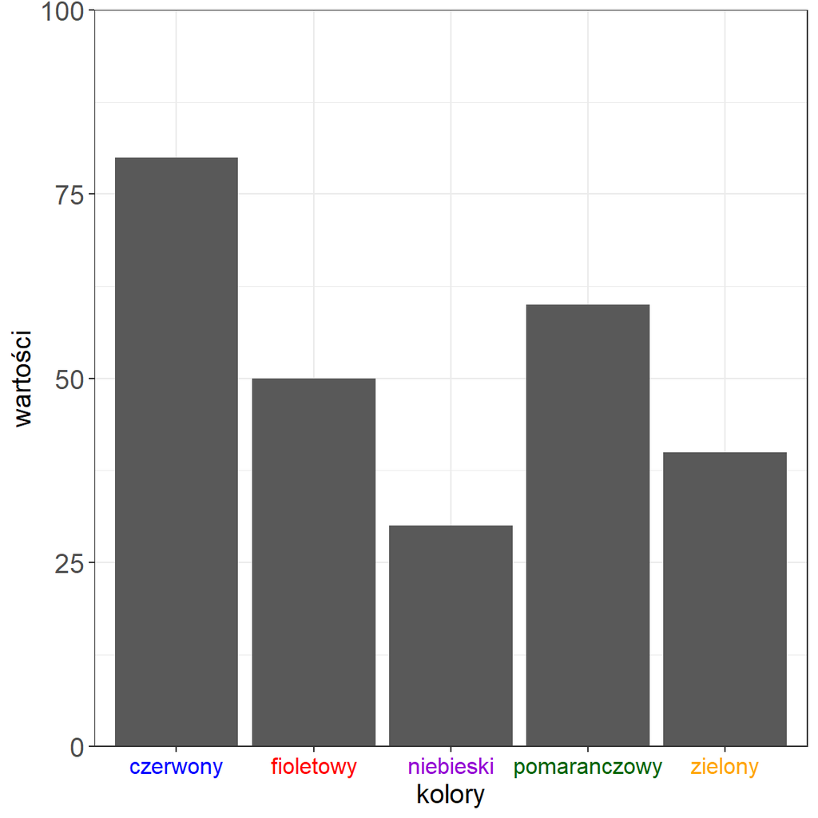

**Oczekiwana odpowiedź:** czerwony, pomarańczowy, fioletowy, zielony, niebieski

## 4.) Błędny błędny kolor osi x oraz kolumn

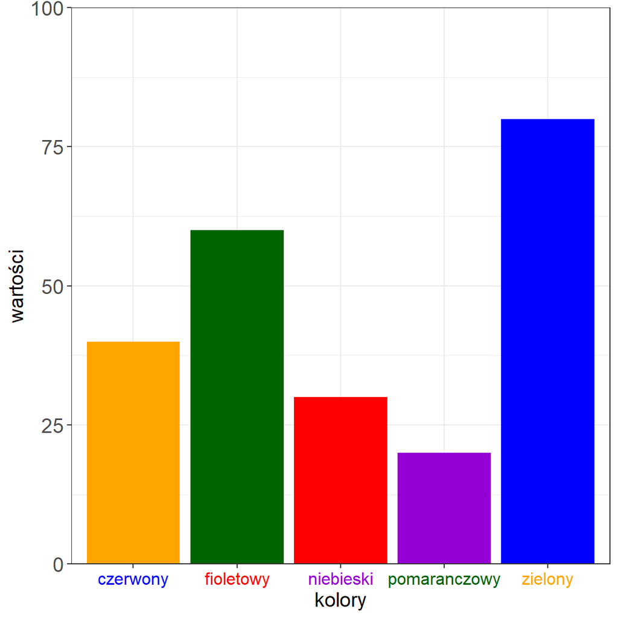

**Oczekiwana odpowiedź:** zielony, fioletowy, czerwony, niebieski, pomarańczowy

# Wyniki badania

Za bezbłędne wskazanie kolejności wykres uznawałem za zaliczony. Oto jak prezentuje się procent poprawnych odpowiedzi dla każdego wykresu:

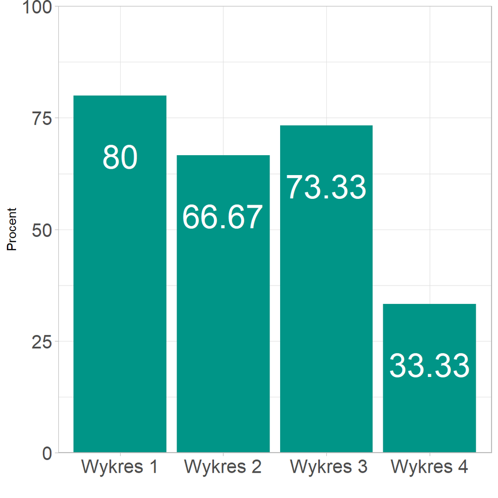

### Bonusowe badanie

Stereotypowo uważa się, że kobiety lepiej sobie radzą z zapamiętywaniem kolorów. Tak przedstawia się wykres poprawnych odpowiedzi z podziałem na płeć

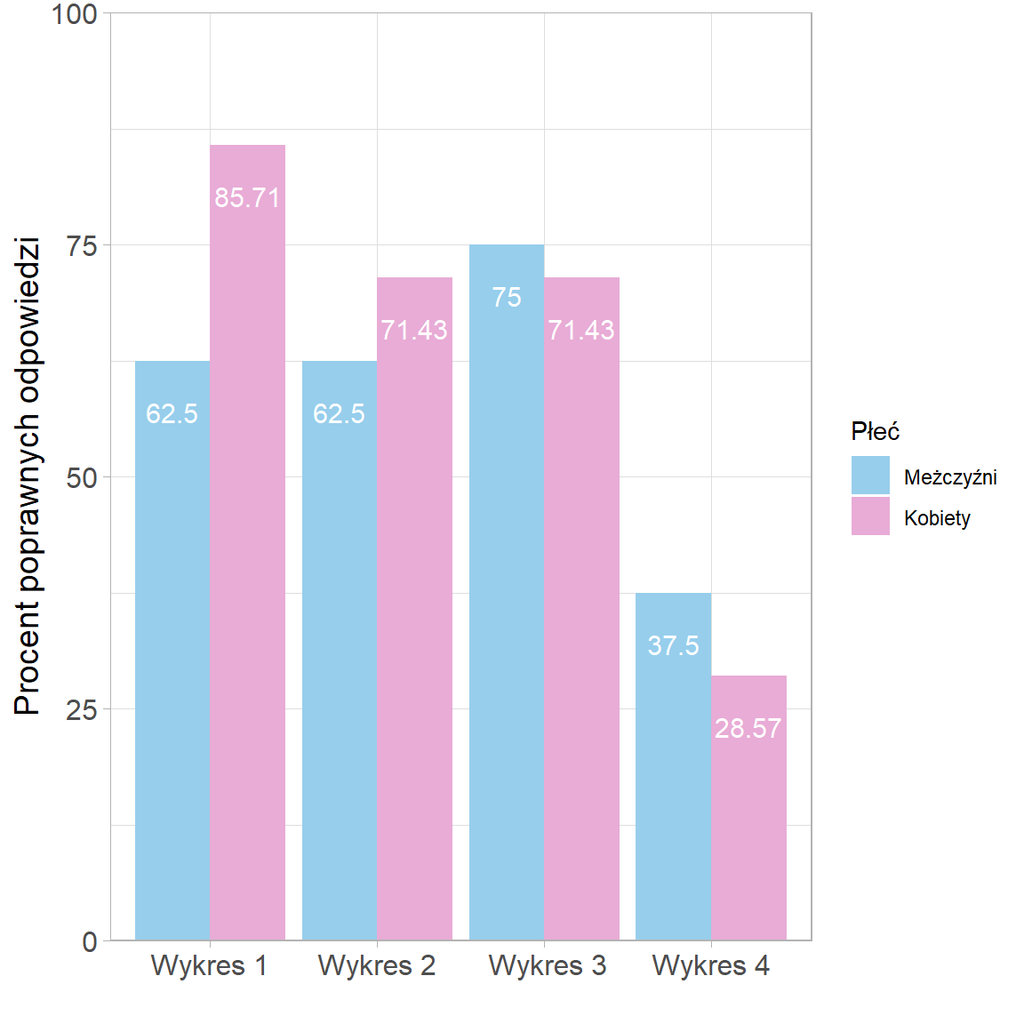

### Wnioski

Na podstawie wykresów możemy stwierdzić, że intuicyjne kolorowanie wpływa na zapamiętywanie danych. Dobre kolorowanie wypadło najlepiej, lecz wykresy numer 2 i 3 nie odstawały w większym stopniu. Natomiast wykres 4 wypadł zdecydowanie najgorzej. Podczas przeprowadzania ankiety wielokrotnie otrzymywałem informacje, że rozczytanie tego wykresu było zdecydowanie trudniejsze i sprawiało większy problem niż samo zapamiętanie 5 kolorów.

Wyniki mężczyzn oraz kobiet były dosyć podobne, więc stereotyp nie został potwierdzony wśród grupy badanych, natomiast wyniki nie są na tyle jednoznaczne, aby móc go zdecydowanie obalić.